# Aufgaben

## Aufgaben

#### Aufgabe

1. Geben Sie die Funktion für jedes Diagramm an!
   1. Diagramm A

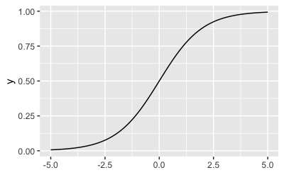

   2. Diagramm B

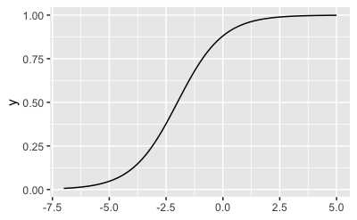

   3. Diagramm C

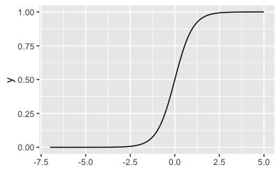

   4. Diagramm 4

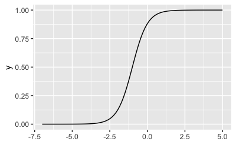

   5. Diagramm 5

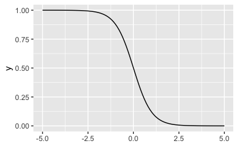

#### Aufgabe

2. Rechnen Sie von Logits in Inv-Logits um!

   Hinweise:
   - Runden Sie auf zwei Dezimalstellen.
   - Orientieren Sie sich am Vorgehen aus dem Unterricht.
   1. 10
   2. 4
   3. -5

#### Aufgabe

3. Eine logistische Regression wurde an einen Datensatz angepasst. Es ergaben sich folgende Koeffizienten (jeweils Punktschätzer):

   `Konstante = -1.9` `x = 0.7` `z = 0.7`

   `x` ist ein metrischer Prädiktor mit einem Range von 0 bis 10; `z` ist eine binäre Variable mit den Werten 0 und 1.

   Visualisieren Sie die Kurven in einem Diagramm für
   1. $\mathcal{L}$ vs. $x$
   2. $Pr(y=1)$ vs. $x$

#### Aufgabe

4. *Forschungsfrage*: Ist der Zusammenhang von Körpergröße und ‘Mann’ positiv? Gehen also höhere Werte in Körpergröße `height` einher mit einer höheren Wahrscheinlichkeit, dass es sich um einen Mann `m` handelt?

   Berechnen Sie ein Bayes-Modell und geben Sie die Punktschätzer der Modellkoeffizienten an - einmal für `height` in Inches und einmal in Zentimeter.

   Hinweise:
   - Geben Sie `1` ein für “ja” und `0` für nein.
   - Gleichen sich Koeffizienten bis einschließlich der 1. Dezimale, so gelten sie als “gleich”.
   - Nutzen Sie Standardwerte von `stan_glm()` für Ihr Modell.
   - Entfernen Sie fehlende Werte wo nötig.
   - Gehen Sie von unzentrierten Daten aus, soweit nicht anders angegeben.
   1. Handelt es sich bei der Transformation (von Inches in Zentimeter) um eine lineare Transformation?
   2. Ändert sich der Punktschätzer des Achsenabschnitts durch die Transformation?
   3. Ändert sich der Punktschätzer des Regressionsgewichts durch die Transformation?
   4. Bei zentrierten Daten: Ändert sich der Punktschätzer des Regressionsgewichts durch die Transformation?

#### Aufgabe

5. Betrachten Sie den Datensatz `mtcars`. Die Forschungsfrage betreffe den Einfluss vom Spritverbrauch, $x$, UV, auf die Wahrscheinlichkeit, dass es sich um ein Auto mit Automatik-Schaltung, $y$, AV, handelt.

   Hinweise:
   - Runden Sie auf zwei Dezimalstellen.
   - Berechnen Sie ein lineares Modell auf Basis der Bayes-Statistik.
   - Orientieren Sie sich am Vorgehen aus dem Unterricht.
   1. Was ist der Punktschätzer (Median) in Logits für den Prädiktor?
   2. Was ist der Standardfehler (MAD_SD) in Inv-Logits für den Prädiktor?
   3. Was ist die Wahrscheinlichkeit für `am=1` bei einem Auto mit mittlerem Spritverbrauch, $\bar{mpg}$? Berichten Sie den Punktschätzer!

#### Aufgabe

6. Betrachten Sie den Datensatz `mtcars`. Die Forschungsfrage betreffe den Einfluss vom Spritverbrauch, $x$, UV, auf die Wahrscheinlichkeit, dass es sich um ein Auto mit Automatik-Schaltung, $y$, AV, handelt.

   Hinweise:
   - Runden Sie auf zwei Dezimalstellen.
   - Berechnen Sie ein lineares Modell auf Basis der Bayes-Statistik.
   - Orientieren Sie sich am Vorgehen aus dem Unterricht.
   - Gehen Sie von einem Modell mit standardisiertem Prädiktor aus.
   1. Wie groß ist die Ungewissheit (95%-PI) für den Koeffizienten $\beta$ in Logits? Geben Sie die Breite an.
   2. Wie groß ist die Ungewissheit (95%-PI) für $y$ wenn $x=1$, in Wahrscheinlichkeit? Geben Sie die Breite an.
   3. Wie groß ist die Ungewissheit (95%-PI) für den Achsenabschnitt $\beta$ in Logits? Geben Sie die Breite an.

#### Aufgabe

7. Betrachten Sie den Datensatz `mtcars`. Die Forschungsfrage betreffe den Einfluss vom Spritverbrauch, $x$, UV, auf die Wahrscheinlichkeit, dass es sich um ein Auto mit Automatik-Schaltung, $y$, AV, handelt.

   Hinweise:
   - Runden Sie auf zwei Dezimalstellen.
   - Berechnen Sie ein lineares Modell auf Basis der Bayes-Statistik.
   - Orientieren Sie sich am Vorgehen aus dem Unterricht.

   *Was ist der größte (statistische) Effekt des Prädiktors (in Wahrscheinlichkeit)?*

#### Aufgabe

8. Betrachten Sie den Datensatz `mtcars`. Die Forschungsfrage betreffe den Einfluss vom Spritverbrauch, $x_1$, UV1, sowie von der Zahl der Zylinder (als Faktor-Variable), $x_2$, UV2, auf die Wahrscheinlichkeit, dass es sich um ein Auto mit Automatik-Schaltung, $y$, AV, handelt. Modellieren Sie dabei einen Interaktionseffekt.

   Aufgaben:
   1. Überschneiden sich die Graphen der drei Gruppen?
   2. Visualisieren Sie das Modell! Einmal mit der Y-Achse skaliert in Logits…
   3. … einmal mit der Y-Achse skaliert in Wahrscheinlichkeiten.

   Hinweise:
   - Runden Sie auf zwei Dezimalstellen.
   - Berechnen Sie ein lineares Modell auf Basis der Bayes-Statistik.
   - Orientieren Sie sich am Vorgehen aus dem Unterricht.

#### Aufgabe

9. Betrachten Sie den Datensatz `mtcars`. Die Forschungsfrage betreffe den (statistischen) Einfluss von der Zahl der Zylinder, $x_2$, UV, auf die Wahrscheinlichkeit, dass es sich um ein Auto mit Automatik-Schaltung, $y$, AV, handelt. Modellieren Sie keinen Interaktionseffekt.

   Hinweise:
   - Runden Sie auf zwei Dezimalstellen.
   - Berechnen Sie ein lineares Modell auf Basis der Bayes-Statistik.
   - Orientieren Sie sich am Vorgehen aus dem Unterricht.
   - Geben Sie `1` ein für “ja” und `0` für nein.
   - Gleichen sich Koeffizienten bis einschließlich der 1. Dezimale, so gelten sie als “gleich”.
   - Nutzen Sie Standardwerte von `stan_glm()` für Ihr Modell.
   - Entfernen Sie fehlende Werte wo nötig.

   Aufgaben:
   1. Ist die Wahrscheinlichkeit für ein Automatik-Getriebe höher bei `cyl=4` im Vergleich zu `cyl=6`, laut dem Modell? Beziehen Sie sich auf die den Punktschätzer der Post-Verteilung.
   2. Um welchen Wert unterscheidet sich die Wahrscheinlichkeit?

#### Aufgabe

10. Eine Studie untersuchte den Arsengehalt `arsenic` in Brunnen in Bangladesh. Die Forschis untersuchten u.a., ob die Menschen bereit waren, auf einen Brunnen zu wechseln `switch`, der nicht mit Arsen belastet war, und welche Rolle die Entfernung (in Einheiten von 100 Meter, `dist100`) zum nächsten unbelasteten Brunnen spielt.

    Die Daten sind hier zu beziehen:

    ```
    d_path <- "https://raw.githubusercontent.com/avehtari/ROS-Examples/master/Arsenic/data/wells.csv"

    d <- read_csv(d_path)
    ```

    Hier ist das Regressionsmodell:

    ```
    m1 <- stan_glm(switch ~ dist100 + arsenic,
                   family = binomial(link = "logit"),
                   data = d,
                   refresh = 0)
    ```

    ```
    ## stan_glm
    ##  family:       binomial [logit]
    ##  formula:      switch ~ dist100 + arsenic
    ##  observations: 3020
    ##  predictors:   3
    ## ------
    ##             Median MAD_SD
    ## (Intercept)  0.00   0.08
    ## dist100     -0.90   0.10
    ## arsenic      0.46   0.04
    ##
    ## ------
    ## * For help interpreting the printed output see ?print.stanreg
    ## * For info on the priors used see ?prior_summary.stanreg
    ```

    1. Vergleichen Sie zwei Personen mit der gleichen Distanz zum nächsten unbelasteten Brunnen, wobei eine Person einen Arsenwert von 0.5 hat und die andere Person einen Wert von 1.0.

    Wie groß ist der Unterschied in Wahrscheinlichkeit zwischen erster und zweiter Person, den Brunnen zu wechseln (laut dem obigen Modell)?

    Beziehen Sie sich auf die Daten der Post-Verteilung.
    2. Vergleichen Sie zwei Personen mit der gleichen Distanz zum nächsten unbelasteten Brunnen, wobei eine Person einen Arsenwert von 0.5 hat und die andere Person einen Wert von 1.0.

    Wie groß ist der Unterschied in Wahrscheinlichkeit, dass die zweite Person den Brunnen wechselt? Geben Sie einen Punktschätzer auf Basis des Mittelwerts der Post-Verteilung an! Beziehen Sie sich auf die Daten der PPV.
    1. Wie groß ist die Wahrscheinlichkeit bei Frage a?
    2. Wie groß ist die Wahrscheinlichkeit bei Frage b?

#### Aufgabe

11. Eine Studie untersuchte den Arsengehalt `arsenic` in Brunnen in Bangladesh. Die Forschis untersuchten u.a., ob die Menschen bereit waren, auf einen Brunnen zu wechseln `switch`, der nicht mit Arsen belastet war, und welche Rolle die Entfernung (in Einheiten von 100 Meter, `dist100`) zum nächsten unbelasteten Brunnen spielt.

    Die Daten sind hier zu beziehen:

    ```
    d_path <- "https://raw.githubusercontent.com/avehtari/ROS-Examples/master/Arsenic/data/wells.csv"

    d <- read_csv(d_path)
    ```

    Hier ist ein Regressionsmodell mit Interaktionseffekt:

    ```
    m2 <- stan_glm(switch ~ dist100 + arsenic + dist100:arsenic,
                   family = binomial(link = "logit"),
                   data = d,
                   refresh = 0)
    ```

    ```
    print(m2, digits = 2)
    ```

    ```
    ## stan_glm
    ##  family:       binomial [logit]
    ##  formula:      switch ~ dist100 + arsenic + dist100:arsenic
    ##  observations: 3020
    ##  predictors:   4
    ## ------
    ##                 Median MAD_SD
    ## (Intercept)     -0.15   0.12
    ## dist100         -0.58   0.21
    ## arsenic          0.56   0.07
    ## dist100:arsenic -0.18   0.10
    ##
    ## ------
    ## * For help interpreting the printed output see ?print.stanreg
    ## * For info on the priors used see ?prior_summary.stanreg
    ```

    Und hier das Modell mit gleichen Prädiktoren, aber zentrierten Prädiktoren:

    ```
    d2 <-
      d %>%
      select(dist100, arsenic, switch) %>%
      drop_na() %>%
      mutate(dist100_c = dist100 - mean(dist100),
             arsenic_c = arsenic - mean(arsenic))

    m3 <- stan_glm(switch ~ dist100_c + arsenic_c + dist100_c:arsenic_c,
                   family = binomial(link = "logit"),
                   data = d2,
                   refresh = 0)
    ```

    ```
    print(m3, digits = 2)
    ```

    ```
    ## stan_glm
    ##  family:       binomial [logit]
    ##  formula:      switch ~ dist100_c + arsenic_c + dist100_c:arsenic_c
    ##  observations: 3020
    ##  predictors:   4
    ## ------
    ##                     Median MAD_SD
    ## (Intercept)          0.35   0.04
    ## dist100_c           -0.87   0.10
    ## arsenic_c            0.47   0.04
    ## dist100_c:arsenic_c -0.18   0.10
    ##
    ## ------
    ## * For help interpreting the printed output see ?print.stanreg
    ## * For info on the priors used see ?prior_summary.stanreg
    ```

    Warum hat das *nicht* zentrierte Modell größere Standardfehler (MAD_sd)?